# Lab 8: Evaluating Conditions & Conducting Hypothesis Tests

```r
library(tidyverse)
library(gapminder)
library(infer)
library(moderndive)
```

# Today’s Data

Here is a decription of the `gapminder` dataset as written by two of your peers:

> The gapminder dataset contains data representing three numerical attributes of a country: its average life expectancy in years, its population, and its per-capita GDP in “international dollars” (a hypothetical currency with the purchasing power of the U.S. dollar in 2005).

> GDP data from years 1990 to 2019 come from the World Bank, which was published in May 2022. Data from previous years come from the Madison Project Database and the Penn World Table. The life expectancy data were compiled from three main sources: Mattias Lindgren and Klara Joahansson, gapminder version 7 (1800-1970), the Institute for Health Metrics and Evaluation (1970-2016), and the United Nations population data (2017-present). The geographical data for country and continent are based off of current borders as determined by the United Nations.

> In total, there are 1704 observations and 6 variables, with the country variable being a factor containing 142 levels. The data were retrieved in 2008 and 2009 from [Gapminder](https://gapminder.org/), an organization that collects world data. The dataset was also manually cleaned by Dr. Jenny Bryan and her STAT 545 students.

> Gapminder itself collected its GDP data from the World Bank, its life expectancy data from various studies published by the Institute for Health Metrics and Evaluation, and its population data from the US Census Bureau.

## Question of Interest

The objective of this data analysis is to answer the question:

> What is the relationship between life expectancy GDP per capita?

# Exploratory data analysis

Let’s load the `gapminder` data into our workspace and start exploring!

```r
data(gapminder)
```

## Data Visualization

**1. Create a scatterplot of the relationship between life expectancy (response) and GDP (explanatory).**

*Remember to include nice axis labels (with units!).*

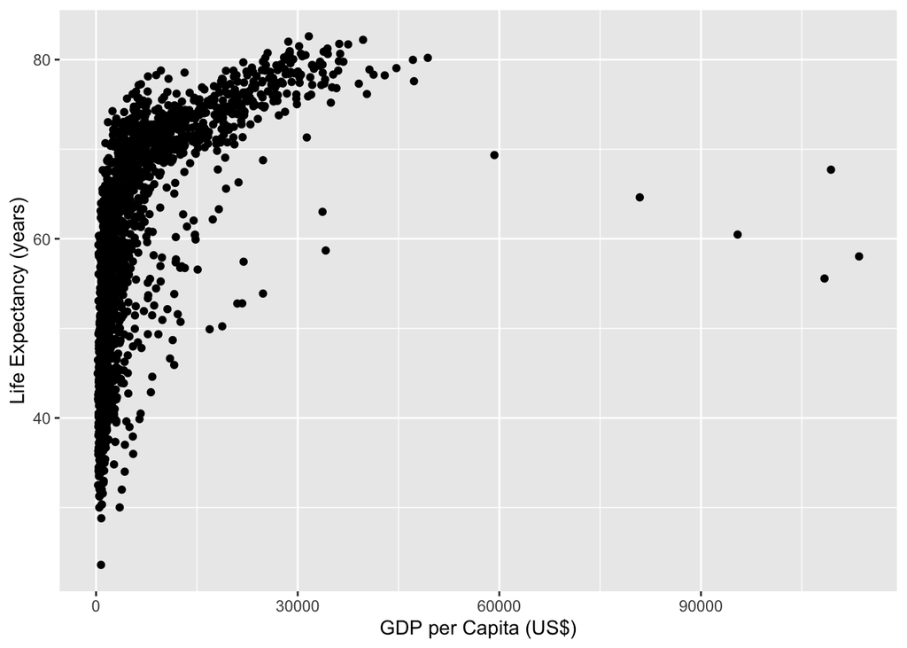

```r
ggplot(data = gapminder,
       mapping = aes(y = lifeExp,
                     x = gdpPercap)) +
  geom_point() +
  labs(x = "GDP per Capita (US$)",
       y = "Life Expectancy (years)")
```

What you see should make you concerned about using a linear regression! So, let’s play with some variable transformations.

You can explore if a log-transformation of the y-variable would make the relationship more linear by adding a `scale_y_log10()` layer to your plot, like so:

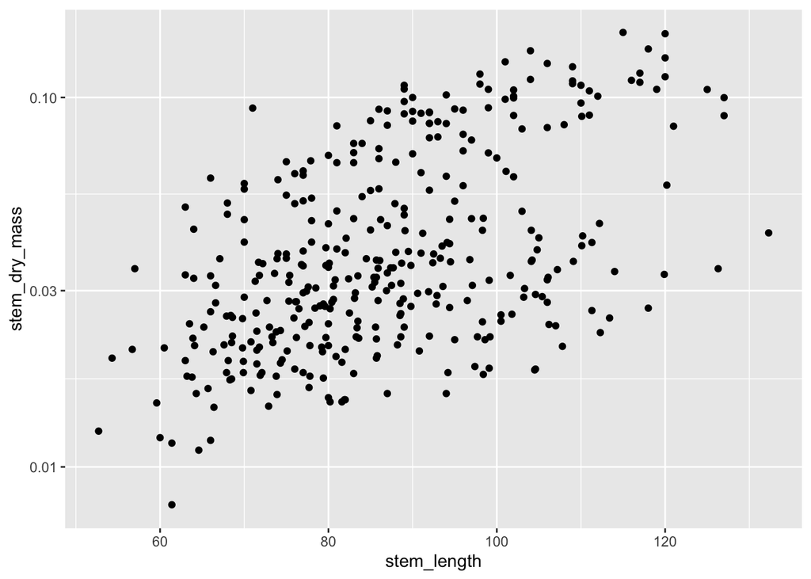

```r
lterdatasampler::hbr_maples %>%
  ggplot(mapping = aes(x = stem_length, y = stem_dry_mass)) +
  geom_point() +
  scale_y_log10()
```

Similarly, you can a log-transformation of the x-variable would be helpful by adding a `scale_x_log10()` layer to your plot.

**2. Using `scale_x_log10()` and `scale_y_log10()`, decide on what relationship between life expectancy and GDP per capita appears the most linear.**

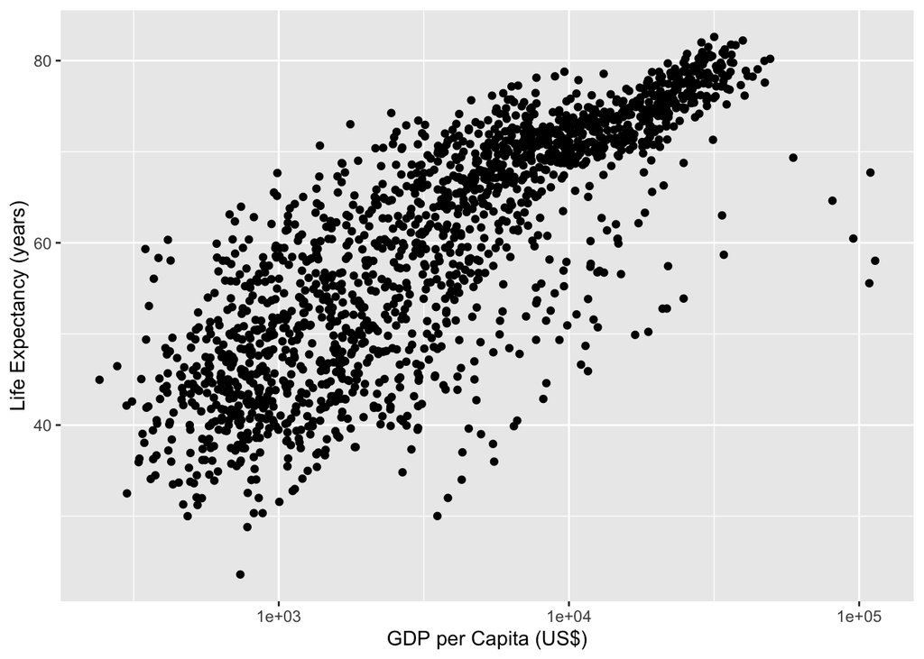

```r
ggplot(data = gapminder,
       mapping = aes(y = lifeExp,
                     x = gdpPercap)) +
  geom_point() +
  labs(x = "GDP per Capita (US$)",
       y = "Life Expectancy (years)") +
  scale_x_log10()
```